# A fast R program to detect allelic imbalances using SNP array data with MAD

Juan R. Gonzalez

Institute for Global Health (ISGlobal), Barcelona, Spain Bioinformatics Research Group in Epidemiolgy (BRGE) http://brge.isglobal.org

2018-11-05

#### Package

mad 1.1.2

# 1 Introduction

MAD (mosaic alteration detector) is a fast algorithm to detect allelic imbalances using SNP array data (B-allele frequency (BAF) and log R ratio (LRR). The method detects different types of mosaic alterations (UPDs, deletions, duplications and trisomies) by searching for segments were B-deviation is different from 0. Segmentation procedure is carried out using an *R* implementation of GADA algorithm (Pique-Regi R, Caceres A, Gonzalez JR. BMC Bioinformatics, 2010). R-GADA is available at https://github.com/isglobal-brge/R-GADA.

Herein, we briefly describe how to use the main functions by using a real data set of 5 samples: *CASE369.txt*, *CASE371.txt*, *CASE377.txt*, *CONTROL152.txt*, *CONTROL191.txt*. These files can be loaded into *R* from our package called `brgedata` which is also available at our GitHub repository https://github.com/isglobal-brge/brgedata.

# 2 Getting Started

The package depends on R-GADA package that can be installed from our GitHub repository:

```r
devtools::install_github("isglobal-brge/R-GADA")
```

After that, MAD can be installed by

```r
devtools::install_github("isglobal-brge/MAD")
```

The package is loaded as usually

```r
library(mad)
```

# 3 Required data format

Detection of mosaic alterations enforces a strict directory structure on the working directory to perform the analysis of multiple samples. Nonetheless, the only required directory to be set up by the user is that containing the raw data. This is an example of how data are organized before the analysis is completed

- rawData
  - CASE369.txt
  - CASE371.txt
  - CASE377.txt
  - CONTROL152.txt
  - CONTROL191.txt

Notice that *rawData* directory contains all data files corresponding to each individual from a particular assay. Each text file must be prepared in pennCNV format http://http://penncnv.openbioinformatics.org. This can be performed by using the BeadStudio tool when analyzing Illumina data (see http://www.illumina.com/), or Affymetrix power tools (see https://www.affymetrix.com/ or other Bioconductor packages if Affymetrix SNP data is analyzed: *crlmm*, *affy2sv*, etc. This is the structure of a given example:

```
Name       Chr Position   Log.R.Ratio B.Allele.Freq GType
rs758676   7   12878632   0.1401      0.4977        AB
rs3916934  13  103143536  0.3934      0.4610        AA
rs2711935  4   38838852  -0.1091      0.0026        AA
rs17126880 1   64922104   0.0478      0.9910        AA
rs12831433 12  4995220   -0.1661      0.0000        AA
```

It is important to mention that all files included in the folder *rawData* must belong to the same type of array (e.g. same number of probes) because the annotation data is obtained from one of these files. If samples have been analyzed using different platforms, the best option is to create another working directory containing another *rawData* folder.

# 4 Importing array data

Let us prepare a `rawData` folder containing 5 files in the required format. PennCNV files are available in our package called `brgedata` that can be installed by executing:

```r
devtools::install_github("isglobal-brge/brgedata")
```

Once `brgedata` package is available in your computer we can copy the required files into a `rawData` folder by executing

```r
ss1 <- system.file("extdata/madData", package="brgedata")
dir.create("rawData")
ss2 <- "rawData"
files <- list.files(ss1)
file.copy(file.path(ss1,files), ss2)
```

```
## [1] FALSE FALSE FALSE FALSE FALSE
```

As a result, our working directory contains a folder called `rawData` having all the files we want to process.

```r
dir()
```

```
## [1] "MAD.html" "MAD.Rmd"  "rawData"  "SBL"
```

```r
dir("rawData")
```

```
## [1] "CASE369.txt"    "CASE371.txt"    "CASE377.txt"    "CONTROL152.txt"
## [5] "CONTROL191.txt"
```

we are ready to start the analyses. First, data can be prepared for the analysis by:

```r
example <- setupParGADA.B.deviation(NumCols=6, GenoCol=6,
                                    BAFcol=5, log2ratioCol=4)
```

```
##
## Creating object with annotation data ...
## Creating object with annotation data ...done
##
## Creating objects of class setupGADA for all input files...
##   Applying setupGADA.B.deviation for 5 samples ...
##   Importing array:  CASE369.txt ...    Array # 1 ...done
##   Importing array:  CASE371.txt ...    Array # 2 ...done
##   Importing array:  CASE377.txt ...    Array # 3 ...done
##   Importing array:  CONTROL152.txt ...    Array # 4 ...done
##   Importing array:  CONTROL191.txt ...    Array # 5 ...done
##   Applying setupGADA.B.deviation for 5 samples ... done
## Creating objects of class setupGADA for all input files... done
```

By default, the function considers that the first column of pennCNV-style files correspond to the marker id (e.g SNP name). The second columd stands for the chromosome name and the third one corresponds to the genomic position. These can be changed by the arguments *MarkerIdCol*, *ChrNameCol* and *ChrPosCol*, respectively. Information about the number of columns of each file (argument *NumCols*) as well as the column containing Genotypes, BAF and LRR are mandatory and should be passed through the arguments *GenoCol*, *BAFcol* and *log2ratioCol*, respectively. The function also contains an argument called *folder* that allow the user to indicate where the *rawData* is located if the working directory does not contains the required `rawData` folder.

The object *example* contains the following information:

```r
example
```

```
## [1] "C:/Juan/CREAL/GitHub/MAD/vignettes"
## attr(,"class")
## [1] "parGADA"
## attr(,"labels.samples")
## [1] "CASE369"    "CASE371"    "CASE377"    "CONTROL152" "CONTROL191"
## attr(,"Samples")
## [1] 5
## attr(,"b.deviation")
## [1] TRUE
```

# 5 Segmentation procedure

Segmentation is performed by using two consecutive algorithms implemented in two separate R-functions whithin the `gada` package. The first function (`parSBL`) uses sparse Bayesian learning (SBL) to discover the most likely positions and magnitudes for a segment, i.e. the breakpoints. The SBL model is governed by a hierarchical Bayesian prior, which is uninformative with respect to the location and magnitude of the copy number changes but restricts the total number of breakpoints. Sensitivity, given by the maximum breakpoint sparseness, is controlled by the hyperparameter `aAlpha`. The second function (`parBE`) is an algorithm that uses a backward elimination (BE) strategy to rank the statistical significance of each breakpoint obtained from `SBL`. We have programmed another function called `parBE.B.deviation` to detect segments that can be considered as an allelic imbalance. The results from `parSBL` and `parBE.B.deviation` are stored in separate files, one for each sample, in a folder called `SBL`.

Therefore, the segmentation procedure can be performed by executing two steps:

```r
parSBL(example, estim.sigma2=TRUE, aAlpha=0.8)
```

```
## Creating SBL directory ...done
## Retrieving annotation data ...done
## Segmentation procedure for 5 samples ...
##    Array # 1 ...    The estimated sigma2 = 0.910931
##    Array # 1 ...done
##    Array # 2 ...    The estimated sigma2 = 0.754135
##    Array # 2 ...done
##    Array # 3 ...    The estimated sigma2 = 1.043872
##    Array # 3 ...done
##    Array # 4 ...    The estimated sigma2 = 0.9110874
##    Array # 4 ...done
##    Array # 5 ...    The estimated sigma2 = 0.371038
##    Array # 5 ...done
## Segmentation procedure for 5 samples ...done
```

and

```r
parBE.B.deviation(example, T=9, MinSegLen=100)
```

```
## Retrieving annotation data ...done
## Backward elimination procedure for 5 samples ...
##    Array # 1 ... ----------------------------------------
## Sparse Bayesian Learnig (SBL) algorithm
## Backward Elimination procedure with T=9 and minimun length size=100
##  Number of segments =  53
##  Base Amplitude of copy number 2: chr 1:22:0.558, X=0.0167, Y=0
##    Array # 2 ... ----------------------------------------
## Sparse Bayesian Learnig (SBL) algorithm
## Backward Elimination procedure with T=9 and minimun length size=100
##  Number of segments =  43
##  Base Amplitude of copy number 2: chr 1:22:0.3779, X=0.0226, Y=0
##    Array # 3 ... ----------------------------------------
## Sparse Bayesian Learnig (SBL) algorithm
## Backward Elimination procedure with T=9 and minimun length size=100
##  Number of segments =  68
##  Base Amplitude of copy number 2: chr 1:22:0.705, X=0.0517, Y=0
##    Array # 4 ... ----------------------------------------
## Sparse Bayesian Learnig (SBL) algorithm
## Backward Elimination procedure with T=9 and minimun length size=100
##  Number of segments =  66
##  Base Amplitude of copy number 2: chr 1:22:0.6464, X=0.0431, Y=0
##    Array # 5 ... ----------------------------------------
## Sparse Bayesian Learnig (SBL) algorithm
## Backward Elimination procedure with T=9 and minimun length size=100
##  Number of segments =  35
##  Base Amplitude of copy number 2: chr 1:22:0.2624, X=0.0028, Y=0
## Backward elimination procedure for 5 samples ...done
```

Anyway the backward elimination procedure is very fast and the user can change the parameter `T` and obtain different results. The argument `MinSegLen` indicates the number of consecutive probes that have a B-deviation different from 0.

# 6 Obtaining allelic imbalance regions

The function `getMosaics` creates a `GenomicRanges` object which includes the altered regions:

```r
mosaics <- getMosaics(example)
mosaics
```

```
## GRanges object with 42 ranges and 6 metadata columns:
##        seqnames              ranges strand |  LenProbe       LRR    LRR.se
##           <Rle>           <IRanges>  <Rle> | <integer> <numeric> <numeric>
##    [1]     chr6   31578652-32298368      * |      1522         0      0.14
##    [2]     chr8   41574161-49215718      * |      1266      0.01      0.25
##    [3]     chr9 130037713-131048917      * |       525      0.02      0.15
##    [4]    chr14   65674121-66989436      * |       477      0.04      0.17
##    [5]    chr15   40160724-43767684      * |      1599      0.02      0.19
##    ...      ...                 ...    ... .       ...       ...       ...
##   [38]    chr16   31688557-47128764      * |      1186     -0.05      0.29
##   [39]    chr16   64931218-66531454      * |       796     -0.03      0.21
##   [40]     chrX         814-2663913      * |       501     -0.14      0.32
##   [41]    chr20   14405834-44638545      * |     11501     -0.12      0.29
##   [42]    chr20   44638889-48596642      * |      1763     -0.22      0.29
##             Bdev     State      sample
##        <numeric> <numeric> <character>
##    [1]     0.243         5     CASE369
##    [2]     0.315         5     CASE369
##    [3]     0.204         5     CASE369
##    [4]     0.323         5     CASE369
##    [5]     0.245         5     CASE369
##    ...       ...       ...         ...
##   [38]     0.354         1  CONTROL152
##   [39]      0.32         1  CONTROL152
##   [40]     0.314         2  CONTROL152
##   [41]     0.108         2  CONTROL191
##   [42]     0.199         2  CONTROL191
##   -------
##   seqinfo: 16 sequences from an unspecified genome; no seqlengths
```

The column `State` is a preliminary attempt to classify mosaic alterations after MAD calling process based on log2-ratio segment values (LRR) together with the percentage of normal heterozygous (BAF $\sim$ 0.5) and homozygous probes. The number codes correspond to the following abnormalities: UPD (1), deletion (2), duplication (3), trisomy (4) and LOH (5). It is recommendable to check called segments by making chromosome plots and observing LRR and BAF values to confirm those segments with limit cut-off values. The column `Bdev` stands for B-deviation that can be used to estimate cellularity. Our experience by analyzing several real datasets is that the method is highly sensible to detect alterations having B-deviations larger than 0.05.

LOH can be removed from the candidate list by simply

```r
mosaics <- subset(mosaics, State!=5)
mosaics
```

```
## GRanges object with 30 ranges and 6 metadata columns:
##        seqnames             ranges strand |  LenProbe       LRR    LRR.se
##           <Rle>          <IRanges>  <Rle> | <integer> <numeric> <numeric>
##    [1]    chr17  41256855-78653169      * |     14847      0.02      0.22
##    [2]     chr5  68559889-70713219      * |       326     -0.04      0.54
##    [3]     chr6  27829009-28892085      * |       677     -0.04       0.2
##    [4]     chr7  98729374-99331596      * |       353     -0.03      0.15
##    [5]     chr8 99614736-101063565      * |       583     -0.05      0.24
##    ...      ...                ...    ... .       ...       ...       ...
##   [26]    chr16  31688557-47128764      * |      1186     -0.05      0.29
##   [27]    chr16  64931218-66531454      * |       796     -0.03      0.21
##   [28]     chrX        814-2663913      * |       501     -0.14      0.32
##   [29]    chr20  14405834-44638545      * |     11501     -0.12      0.29
##   [30]    chr20  44638889-48596642      * |      1763     -0.22      0.29
##             Bdev     State      sample
##        <numeric> <numeric> <character>
##    [1]     0.246         1     CASE369
##    [2]     0.498         1     CASE377
##    [3]     0.409         1     CASE377
##    [4]     0.322         1     CASE377
##    [5]     0.211         1     CASE377
##    ...       ...       ...         ...
##   [26]     0.354         1  CONTROL152
##   [27]      0.32         1  CONTROL152
##   [28]     0.314         2  CONTROL152
##   [29]     0.108         2  CONTROL191
##   [30]     0.199         2  CONTROL191
##   -------
##   seqinfo: 16 sequences from an unspecified genome; no seqlengths
```

For those users who are not familiar with `GenomicRanges` the resulting information can be obtained as a `data.frame` and exported into a text file by simply writting:

```
altered <- as(mosaics, "data.frame")
head(altered)
write.table(altered, file="file.txt", quote=FALSE, sep="\t",
            row.names=FALSE)
```

The user can change `T` parameter to get more candidate regions. It should be consider that lower values of `T` argument will increase false positive results. We start by executing

```
parBE.B.deviation(example, T=7, MinSegLen=75)
```

and then the new altered regions can be obtained by:

```
mosaics2 <- getMosaics(example)
```

# 7 Data visualization

The user can visually inspect the BAF and LRR of given region to verify wheather it is a real mosaic alteration. The function `plotQMosaic` can be used to this end:

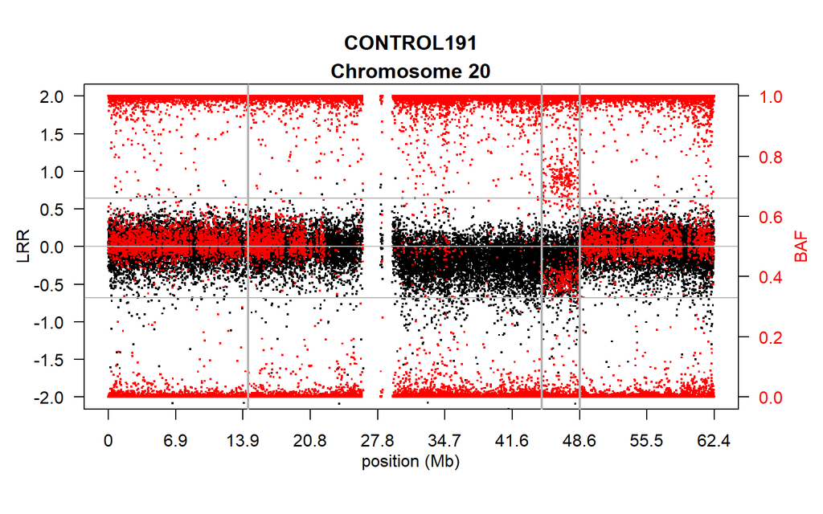

```r
example <- addAnnot(example) # add annotation
plotQMosaic(example, sample="CONTROL191", chr=20,
            regions=mosaics)
```

We can also zoom out the region of interest. For instance, let us better visualize the second alteration of CONTROL191 individual that can be accessed by

```r
library(GenomicRanges)
mosaics[mosaics$sample=="CONTROL191" &
          seqnames(mosaics)=="chr20"]
```

```
## GRanges object with 2 ranges and 6 metadata columns:
##       seqnames            ranges strand |  LenProbe       LRR    LRR.se
##          <Rle>         <IRanges>  <Rle> | <integer> <numeric> <numeric>
##   [1]    chr20 14405834-44638545      * |     11501     -0.12      0.29
##   [2]    chr20 44638889-48596642      * |      1763     -0.22      0.29
##            Bdev     State      sample
##       <numeric> <numeric> <character>
##   [1]     0.108         2  CONTROL191
##   [2]     0.199         2  CONTROL191
##   -------
##   seqinfo: 16 sequences from an unspecified genome; no seqlengths
```

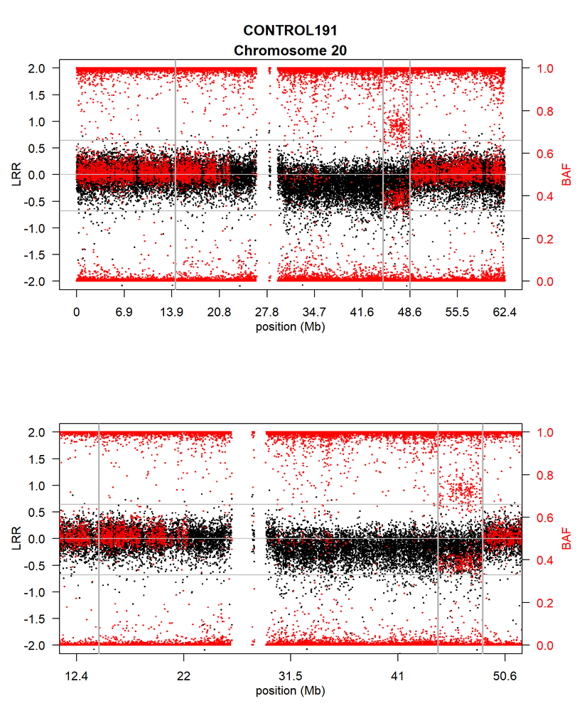

```r
plotZoomQMosaic(example, sample="CONTROL191", chr=20,
            regions = mosaics[mosaics$sample=="CONTROL191" &
                                seqnames(mosaics)=="chr20"])
```

[figure not shown]

```r
library(Gviz)
library(Homo.sapiens)
rr <- GRanges("chr16:63.5e6-67.0e6")
plotCNVs(mosaics, range=rr, mosaic=TRUE, drawGenes = TRUE)
```

Mosaic segments at individual level can be plotted using `GenVisR` Bioconductor package. The legend correspond to: UPD (1), deletion (2), duplication (3), trisomy (4).

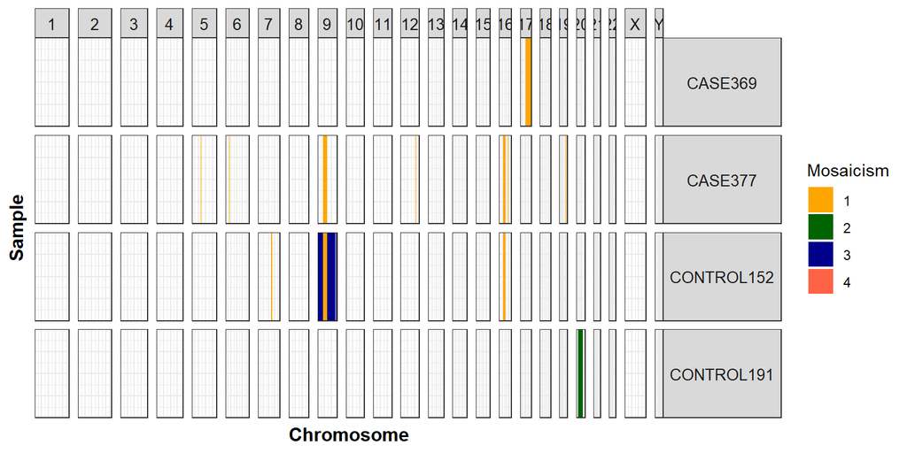

```r
library(ggplot2)
plotSegments(mosaics)
```